# IMF Online Course: Macroeconomic forecasting

## Module 3A: Statistical Properties of Time Series Data

### Introduction to Time Series Data

**Author**: Miha Trošt  
**Date**: 29-01-2016

```r
# useful libraries
library(plyr)
library(dplyr)
library(forecast)
library(stringr)
library(lubridate)
library(tidyr)
library(broom)
```

```r
my_wd <-
  "C:/Users/Miha/Documents/GitHub/IMF_Macro_Forecasting_R/002_module_3a_Statistical_properties_of_time_series/"

my_file <-
  str_c(my_wd, "Module3_data/module3_data_Identifying_ARMA.csv")

m3_data <- read.csv(my_file, sep = "")
```

#### Question 3.8

Open the EViews workfile M3_data.wf1 and click on the sheet “Identifying_ARMA”. The variable et represents a random shock variable. Provide the average and standard-deviation of et below (to three decimal places, without any rounding. For example, if the number is 2.535986, input 2.535).

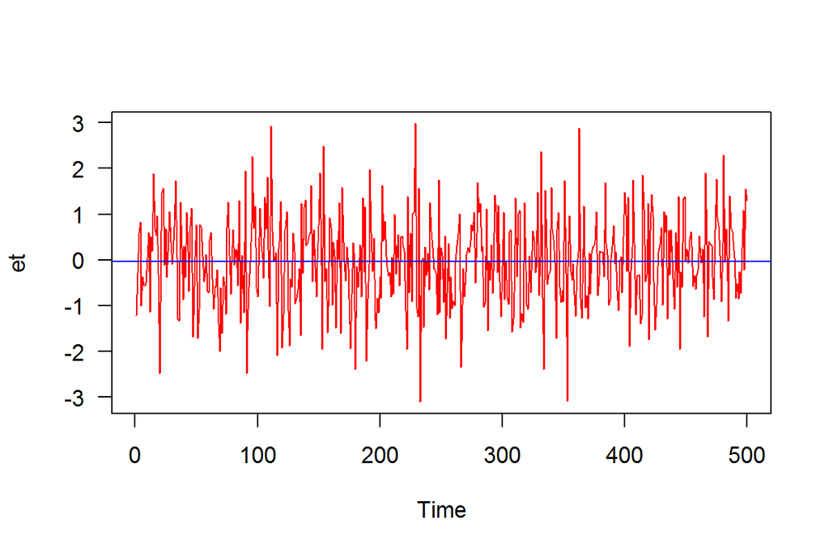

```r
# visual inspection
par(las = 1)
plot.ts(m3_data, col = "red")
abline(h = mean(m3_data$et), col = "blue")
```

The `et` time series **mean** is -0.0284598 and its **standard deviation** is 0.9819995.

#### Question 3.9

Using et as the white noise disturbance, and assuming the initial value of y to be equal to zero generate a new random variable yar, which follows the following AR(1) process:

`yt = 3.0 + 0.55 yt-1 + et; y0 = 0`

Enter the value of the 5th observation of variable yar (to three decimal places, without any rounding):

```r
# reproduction of Eviews simualtions AR(1)

### question 3.9
# yt  = 3.0 + 0.55 yt-1 + et; y0 = 0
y_ar <- as.vector(1)

# y_0 = 0
y_ar[1] <- 0

# generate time series

n <- 500
for (i in 2:n) {

    y_ar[i] <- 3 + m3_data$et[i] + 0.55 * y_ar[i - 1]

}
```

The fifth value is 5.6479627.

#### Question 3.10

Also using et as the white noise disturbance and again assuming that the initial value of y is equal to zero, generate the variable yma which follows the following MA(1) process:

`yt = -2.5 + et + 0.70 et-1`

Enter the value of the 5th observation of variable yma (to three decimal places, without any rounding):

```r
### question 3.10
# yt  = -2.5 + et + 0.70 et-1

y_ma <- as.vector(1)

# y_0 = 0
y_ma[1] <- 0

# generate time series

n <- 500
for (i in 2:n) {

    y_ma[i] <- -2.5 + m3_data$et[i] + 0.7 * m3_data$et[i - 1]

}
```

The fifth value is -2.9154437.

#### Question 3.11

Based on the patterns of ACF and PACF observed in the past lecture for an AR(1) process, which of the following statements is true?

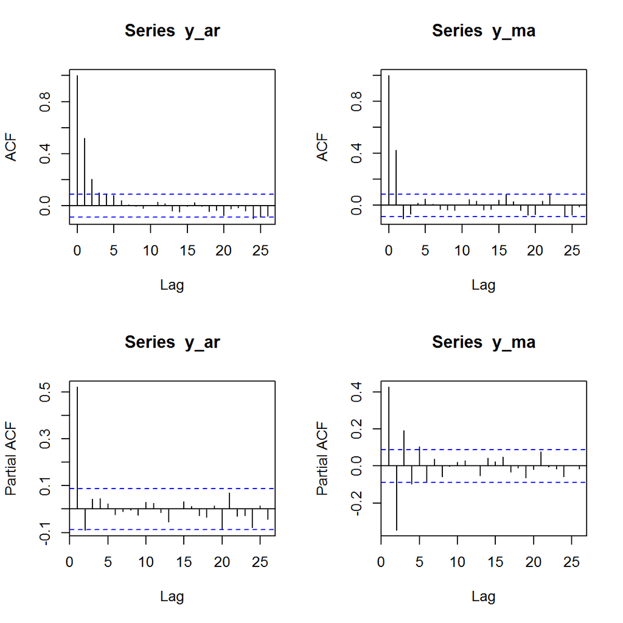

```r
### question 3.11
par(mfrow = c(2, 2))
acf(y_ar); acf(y_ma); pacf(y_ar); pacf(y_ma)
```

```r
par(mfrow = c(1, 1))
```

The second answer is correct: *ACF decays gradually, PACF drops abruptly after lag 1.*

#### Question 3.12

Lastly, also using et as the white noise disturbance and assuming that the initial value of y is equal to zero, generate variable yarma which follows an ARMA(1,1) process:

`yt = 0.5 + 0.55 yt-1 + et + 0.70 et-1`

```r
### question 3.12
# yt = 0.5 + 0.55 yt-1 + et + 0.70 et-1

y_arma <- as.vector(1)

# y_0 = 0
y_arma[1] <- 0

# generate time series

n <- 500
for (i in 2:n) {

    y_arma[i] <-
      0.5 + 0.55 * y_arma[i - 1] + m3_data$et[i] + 0.7 * m3_data$et[i - 1]

}
```

The fifth value is 1.2061956.

#### Question 3.13

Compute the ACF at lags 1-20 for the four series: et and Variables yar,yma and yarma.

Enter the values (using 3 decimal places, without rounding) of the ACF at one lag for each series:

```r
my_lag <- 1

acf(m3_data$et, plot = FALSE)[my_lag]
```

```
Autocorrelations of series 'm3_data$et', by lag

    1
0.024
```

```r
acf(y_ar, plot = FALSE)[my_lag]
```

```
Autocorrelations of series 'y_ar', by lag

    1
0.521
```

```r
acf(y_ma, plot = FALSE)[my_lag]
```

```
Autocorrelations of series 'y_ma', by lag

    1
0.426
```

```r
acf(y_arma, plot = FALSE)[my_lag]
```

```
Autocorrelations of series 'y_arma', by lag

    1
0.727
```

#### Question 3.14

For the theoretical process underlying Variable yar, what would be the ACF for lag 2 (to three decimal places, without any rounding)? It is 0.55 at lag one. For the lag two it should be the square of that number. Hence it would be 0.3025.

#### Question 3.15

Enter the values (using 3 decimal places, without any rounding) for the ACF at two lags for each series:

```r
my_lag <- 2

acf(m3_data$et, plot = FALSE)[my_lag]
```

```
Autocorrelations of series 'm3_data$et', by lag

     2
-0.099
```

```r
acf(y_ar, plot = FALSE)[my_lag]
```

```
Autocorrelations of series 'y_ar', by lag

    2
0.206
```

```r
acf(y_ma, plot = FALSE)[my_lag]
```

```
Autocorrelations of series 'y_ma', by lag

     2
-0.102
```

```r
acf(y_arma, plot = FALSE)[my_lag]
```

```
Autocorrelations of series 'y_arma', by lag

    2
0.331
```

#### Question 3.16

Based on the definition of the partial autocorrelation (PAC) and the patterns of behavior shown in the previous video lecture, what should be the PAC at lags 1 and 2 for the theoretical process underlying Variable y<sub>ar</sub>?

They should be 0.55 at lag 1 and 0 at lag 2.

#### Question 3.17

Use the regression object to estimate the PAC for variable yar for lag 1, then for lag 2.

Enter the PAC for one lag :

```r
my_lm <- lm(y_ar ~ lag(y_ar, 1)) %>%
  tidy

lm(y_ar ~ lag(y_ar, 1)) %>% summary
```

```
Call:
lm(formula = y_ar ~ lag(y_ar, 1))

Residuals:
     Min       1Q   Median       3Q      Max
-3.04879 -0.70262  0.03026  0.65569  3.05001

Coefficients:
             Estimate Std. Error t value Pr(>|t|)
(Intercept)   3.13710    0.24536   12.79   <2e-16 ***
lag(y_ar, 1)  0.52516    0.03675   14.29   <2e-16 ***
---
Signif. codes:  0 '***' 0.001 '**' 0.01 '*' 0.05 '.' 0.1 ' ' 1

Residual standard error: 0.9821 on 497 degrees of freedom
  (1 observation deleted due to missingness)
Multiple R-squared:  0.2913,    Adjusted R-squared:  0.2898
F-statistic: 204.3 on 1 and 497 DF,  p-value: < 2.2e-16
```

PACF for lag 1 is 0.525159. It is statistically significant at 5% level.

#### Question 3.18

Enter the PAC for two lags:

```r
my_lm <- lm(y_ar ~ lag(y_ar, 1) + lag(y_ar, 2)) %>%
  tidy

lm(y_ar ~ lag(y_ar, 1) + lag(y_ar, 2)) %>% summary
```

```
Call:
lm(formula = y_ar ~ lag(y_ar, 1) + lag(y_ar, 2))

Residuals:
     Min       1Q   Median       3Q      Max
-3.15867 -0.70643  0.02768  0.60408  3.10145

Coefficients:
             Estimate Std. Error t value Pr(>|t|)
(Intercept)   3.42376    0.28313  12.093   <2e-16 ***
lag(y_ar, 1)  0.56986    0.04484  12.709   <2e-16 ***
lag(y_ar, 2) -0.08834    0.04356  -2.028   0.0431 *
---
Signif. codes:  0 '***' 0.001 '**' 0.01 '*' 0.05 '.' 0.1 ' ' 1

Residual standard error: 0.9798 on 495 degrees of freedom
  (2 observations deleted due to missingness)
Multiple R-squared:  0.2814,    Adjusted R-squared:  0.2785
F-statistic: 96.93 on 2 and 495 DF,  p-value: < 2.2e-16
```